# Capstone Project

# Load Libraries

```r
library(shapefiles)
```

# Load Data

```r
business <- read_csv("yelp_toronto_business.csv")
review <- read_csv("yelp_toronto_review.csv")
user <- read_csv("yelp_toronto_user.csv")
tip <- read_csv("yelp_toronto_tip.csv")
photo <- read_csv("yelp_toronto_photo.csv")
```

# Exploratory Data Analysis

Our focus will be on the business data, but we will use the review data to get some insights about businesses and will do some feature engineering to create useful variables for the model.

## review data

No missing values.

```r
glimpse(review)
```

```
Observations: 474,803
Variables: 9
$ review_id   <chr> "kS4hrhEScwB9V5JATYjvVQ", "YDJDfKnx6VpMMo4EBxycGg", "2Hk7DNwu3rb2jKHaFfPyCA", ...
$ user_id     <chr> "hxqo4NyJFfeOmuoVi--s1A", "FCtoTo9zSH1cSAkascfEHw", "YHWsLBS8jzZiPjKHMFOaAA", ...
$ business_id <chr> "f5O7v_X_jCg2itqacRfxhg", "7xA6iSP0Ndn08tpBFQtUKA", "SmizR7MLt-558FJJQRBBoQ", ...
$ stars       <int> 5, 1, 4, 4, 2, 3, 2, 3, 4, 4, 2, 5, 4, 5, 4, 1, 1, 4, 3, 3, 3, 4, 3, 3, 1, 2, ...
$ date        <date> 2017-10-12, 2017-05-22, 2011-06-01, 2011-11-07, 2011-08-20, 2011-01-10, 2010-...
$ text        <chr> "Sansotei serves some top notch ramen. They take no reservations, so my compan...
$ useful      <int> 0, 0, 1, 4, 0, 2, 9, 3, 2, 5, 8, 16, 0, 7, 8, 1, 5, 1, 3, 2, 2, 2, 2, 0, 15, 2...
$ funny       <int> 0, 0, 1, 0, 0, 0, 2, 0, 0, 0, 0, 1, 1, 0, 0, 1, 2, 0, 1, 2, 0, 1, 0, 0, 3, 0, ...
$ cool        <int> 0, 0, 1, 0, 0, 1, 4, 2, 1, 3, 1, 9, 0, 0, 3, 0, 1, 2, 2, 1, 2, 1, 0, 0, 1, 2, ...
```

[output not shown]

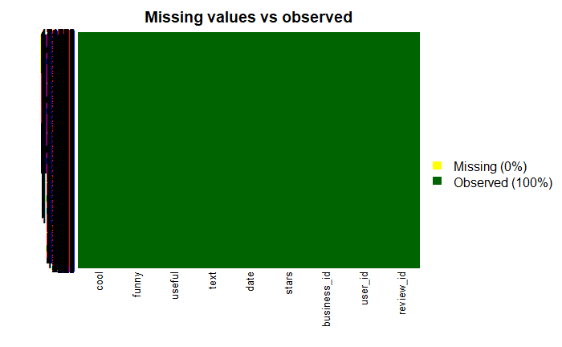

```r
missmap(review, col = c('yellow','darkgreen'), main = 'Missing values vs observed')
```

## Business Data

```r
glimpse(business)
```

```
Observations: 18,233
Variables: 13
$ address      <chr> "631 Bloor St W", "595 Markham Street", "746 Street Clair Avenue W", "99 York...
$ business_id  <chr> "9A2quhZLyWk0akUetBd8hQ", "tZnSodhPwNr4bzrwJ1CSbw", "5J3b7j3Fzo9ISjChmoUoUA",...
$ categories   <chr> "Food, Bakeries", "Cajun/Creole, Southern, Restaurants", "Food, Bakeries, Cof...
$ city         <chr> "Toronto", "Toronto", "Toronto", "Toronto", "Toronto", "Toronto", "Toronto", ...
$ is_open      <int> 0, 0, 1, 0, 1, 1, 1, 1, 0, 0, 1, 1, 1, 1, 0, 1, 1, 1, 0, 1, 1, 1, 1, 1, 1, 1,...
$ latitude     <dbl> 43.66438, 43.66412, 43.68133, 43.67088, 43.73340, 43.66196, 43.66775, 43.7459...
$ longitude    <dbl> -79.41442, -79.41189, -79.42788, -79.39238, -79.22421, -79.39126, -79.39617, ...
$ name         <chr> "Bnc Cake House", "Southern Accent Restaurant", "Mabel's Bakery", "The Coffee...
$ neighborhood <chr> "Koreatown", "Palmerston", "Wychwood", "Yorkville", "Scarborough", "Discovery...
$ postal_code  <chr> "M6G 1K8", "M6G 2L7", "M6C 1B5", "M5R 3K5", "M1M 1P8", "M5S", "M5S 1W2", "M3A...
$ review_count <int> 7, 146, 23, 25, 3, 3, 3, 105, 3, 31, 9, 3, 51, 5, 6, 4, 15, 38, 4, 121, 3, 4,...
$ stars        <dbl> 4.0, 4.0, 4.0, 3.5, 2.0, 4.5, 4.5, 4.0, 3.5, 4.0, 4.0, 1.0, 3.5, 2.0, 2.0, 1....
$ state        <chr> "ON", "ON", "ON", "ON", "ON", "ON", "ON", "ON", "ON", "ON", "ON", "ON", "ON",...
```

[output not shown]

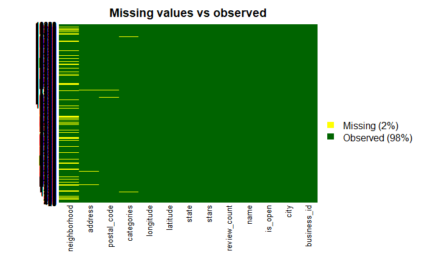

```r
missmap(business, col = c('yellow','darkgreen'), main = 'Missing values vs observed')
```

18,233 Observations and 13 Variables  
$ address character class with 14422 unique values and 283 missing values  
$ business_id character class with 18233 unique values and 0 missing values  
$ categories character class with 10028 unique values and 33 missing values  
$ city character class with 1 unique values and 0 missing values  
$ is_open integer class with 2 unique values and 0 missing values  
$ latitude numeric class with 15366 unique values and 1 missing values  
$ longitude numeric class with 15315 unique values and 1 missing values  
$ name character class with 15292 unique values and 0 missing values  
$ neighborhood character class with 80 unique values and 3435 missing values  
$ postal_code character class with 5261 unique values and 117 missing values  
$ review_count integer class with 380 unique values and 0 missing values  
$ stars numeric class with 9 unique values and 0 missing values  
$ state character class with 2 unique values and 0 missing values

```r
# converting "is_open" attribute from integer to factor and change values to yes or no
#lowering some character variable, converting "stars" from int to factor

business <- business %>%
              mutate(is_open = as_factor(if_else(as.logical(is_open) == TRUE, "yes", "no")),
                     categories = str_to_lower(categories),
                     name = str_to_lower(name),
                     neighborhood = str_to_lower(neighborhood),
                     stars =ordered(as_factor(as.character(stars)), levels = c("1", "1.5", "2", "2.5", "3", "3.5", "4", "4.5", "5"))
                     )
```

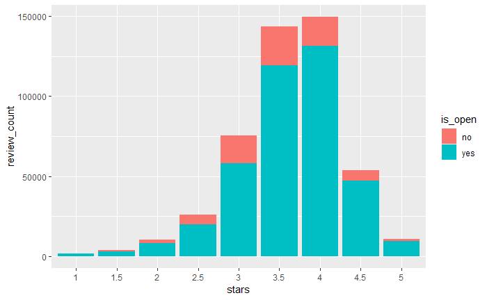

```r
ggplot(business, mapping = aes(stars, review_count, fill =is_open)) +
  geom_col(position = "stack")
```

Businesses “closed” received less reviews, and does not depend of rating. The graph below confirm that assumption.

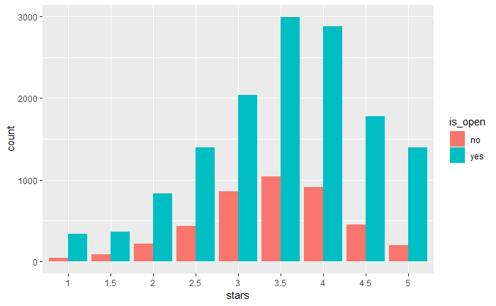

```r
ggplot(business, mapping = aes(stars, fill = is_open)) +
  geom_bar(position = "dodge")
```

Same distribution of rating, may be the closure is not related to the rating.

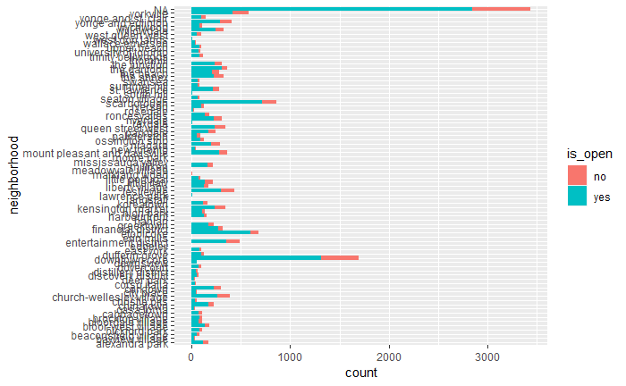

```r
ggplot(business, mapping = aes(neighborhood,  fill =is_open)) +
  geom_bar(position = "stack") +
  coord_flip()
```

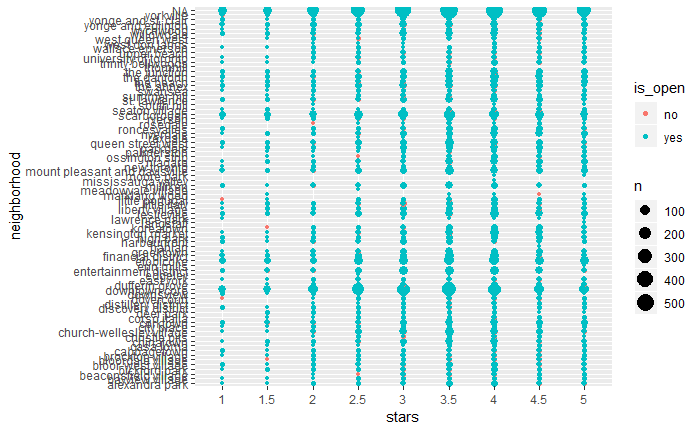

```r
ggplot(business, mapping = aes(stars,  neighborhood, color = is_open)) +
  geom_count()
```

```r
neighborhood <- business %>%
                  select(neighborhood, postal_code) %>%
                  group_by(neighborhood) %>%
                  mutate(code = str_sub(postal_code, 1L, 6L)) %>%
                  arrange(code)
```

```r
map <- map_data(canada.cities$capital)
```

[output not shown]

```r
test <- neighborhood %>%
          select(code, neighborhood, postal_code) %>%
          arrange(code)
```

```r
range_date <- cb_rev %>%
                select(name, business_id, review_count, date) %>%
                group_by(business_id, name, review_count) %>%
                summarise(duration = (max(year(date)) - min(year(date)))) %>%
                arrange(duration)
```

```r
restaurant_neighborhood <- business %>%
                            group_by(neighborhood) %>%
                            summarize(total_review = sum(review_count), mean_stars = round(mean(stars),1)) %>%
                            arrange(desc(total_review))
```

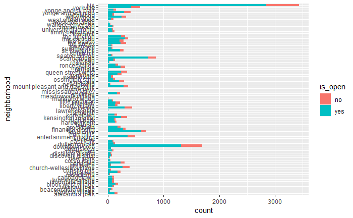

```r
ggplot(business, mapping = aes(x = neighborhood, fill = is_open)) +
geom_bar() + coord_flip()
```

[figure not shown]

```r
ggplot(business, mapping = aes(x = neighborhood)) +
  geom_bar(aes(fill = stars))
```

```r
business2 %>% select(-starts_with("hours"), -starts_with("attribute")) %>% filter(city == 'Toronto') %>% unnest(categories) %>%
 select(name, categories)%>%group_by(categories)%>%summarise(n=n())%>%arrange(desc(n))%>%head(20)
```

```r
business2 %>% select(-starts_with("hours"), -starts_with("attribute")) %>% filter(city == 'Toronto') %>% unnest(categories = strsplit(categories, ",")) %>%
 select(name, categories)%>%group_by(categories)%>%summarise(n=n())%>%arrange(desc(n))%>%head(20)

#df %>% unnest(y = strsplit(y, ","))
```

```r
length(unique(business$categories))
```

```r
library(descr)
# Let filter based on transaction type "Renewal"
CrossTable(renew_channel$channel)
```

```r
business2 <- readRDS("business_data.rds")
```

```r
head(checkins)
```

```r
cat <- business2 %>% select(-starts_with("hours"), -starts_with("attribute")) %>% filter(city == 'Toronto') %>% unnest(categories = strsplit(categories, ",")) %>%
 select(name, categories)%>%group_by(categories)%>%summarise(n=n())%>%arrange(desc(n))
```

```r
cat2 <- business2 %>% select(-starts_with("hours"), -starts_with("attribute")) %>% filter(city == 'Toronto') %>% unnest(categories) %>%
 select(name, categories)%>%group_by(categories)%>%summarise(n=n())%>%arrange(desc(n))
```

```r
c <- colnames(business2$attributes)
test <- business2[, c('business_id', c)]
```

```r
closed_count <- review %>%
                  select(business_id, text) %>%
                  mutate(text_count = str_count(review$text, "closed down")) %>%
                  group_by(business_id, text_count) %>%
                  arrange(desc(text_count))
```

# maps

```r
toronto <- get_census(dataset='CA16', regions=list(CMA="35535"),
                         vectors="v_CA16_2397", level='CSD', quiet = TRUE,
                         geo_format = 'sf', labels = 'short')
```

[output not shown]

[output not shown]

M5H 4G1/Coordinates 43.6508° N, 79.3854° W (lat: 43.6508, lon: -79.3854)